# מקורות מידע למתכנני תחבורה

ד"ר עדו קליין

# מהו סרויס?

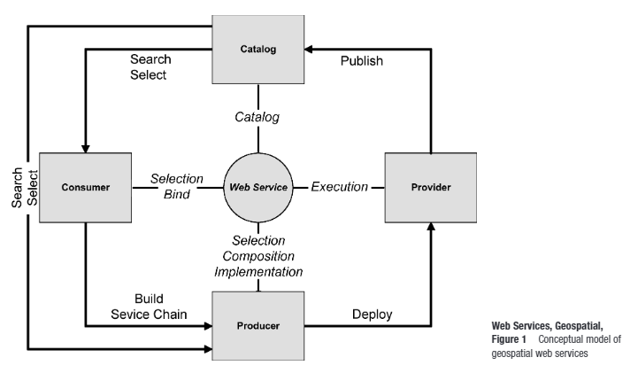

[מכאן](https://www.researchgate.net/publication/235635596_Geospatial_Web_Services)

בגדול, שרתים שמחזיקים מידע גאוגרפי להנגשה חיצונית לצרכי צפייה במידע. לא דאטהבייס שמתעדכן כל הזמן

# איך נתחבר לסרויס?

קודם כל, נשיג כתובת של סרויס, למשל עיריית ירושלים

https://gisviewer.jerusalem.muni.il/arcgis/rest/services/BaseLayers/MapServer

נלך להוספת מידעים, כאן:

נבחר בשרת esri של features

[figure not shown]

new

שם - כרצונכם

כתובת - להעתיק את מה שיש, אישור

הוא יתווסף בדרופדאון של server connections

אבל גם יותר נוח, בbrowser

[figure not shown]

connect - יראה את רשימת השכבות בסרויס. עובד רק עבור ספרית שכבות ולא ספרית ספריות

ניתן להוסיף את השויות שנמצאות במה שמוצג על המפה כעת בלבד (מאוד עוזר לעיתים)

בגרסא 3.14, עבור אורתופוטו או שכבות רקע רסטריות, זה מתבצע על ידי arcgis map service.

# איך נגנוב סרויס?

נניח מצאתם צפיין שעובד עם מוצרי esri. סבירות גבוהה מאוד שתוכלו להוסיף אותו לספריית הסרויסים שלכם.

הדרך המוצעת עובדת עם דפדפן כרום, ולפעמים לא עובדת.

שלב 1: היכנסו לאתר

שלב 2: לחצו על f12

שלב 3:לחצו על טאב network

שלב 4: בחרו באופציה המסומנת - fetch/xhr

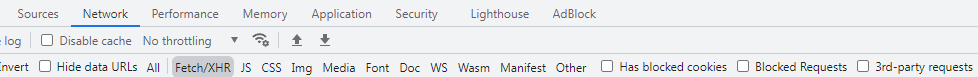

שלב 5: רעננו את הדף, עדיף עם f5

שלב 6: חפשו שאילתות המתחילות בmapserver או featureserver ולחצו עליהן

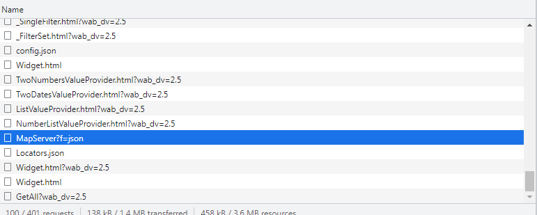

שלב 7: בחלונית הheaders, העתיקו את הrequest url ושימו אותו בדפדפן שלכם, גלשו לאתר. אמור לצאת משהו כזה:

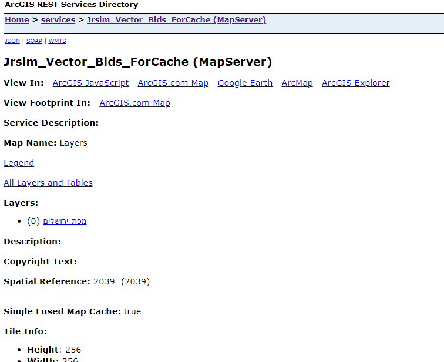

שלב 8: לכו אחורה כמה שניתן, עדיף לservices. העתיקו את הכתובת. הוסיפו את הסרויס.

# איך נייצא/נייבא רשימת סרויסים?

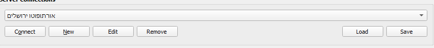

save מאפשר יצירת קובץ xml עם כל הסרויסים שיש למישהו. load מאפשר טעינה של קובץ כזה.

# רשימת הסרויסים שלי

[קישור](https://github.com/idshklein/amav_qgis/blob/master/lesson_5/feature_services.xml)

# טיפים לעבוד עם סרויסים

הם עלולים להיות כבדים. אפשר לייצא אותם לשכבה במחשב, וככה הם ירוצו מהר יותר.

יש להם סימבולוגיה משלהם בדרך כלל. לפעמים היא יכולה מאוד להועיל - אפשר לייצא סגנון אם רוצים לשמור אחר כך.

אפשר להוסיף אותם כשכבות לפרויקט, בלי להוריד אותם. ככה למעשה אפשר לשלוח גאופקג’ שיש בו רק פרויקט, אבל עם המון שכבות מסרויסים. (הסתייגות - אם השרת ירד/השכבה השתנתה, זה עלול לפגוע במטרה שלכם)

# תרגיל

התחברו לסרויס של עיריית ירושלים

סכמו את כמות יחידות הדיור בשכונות העיר (טיפ: השתמשו בפונקציות centroid וcount points in polygon)

(ואולי גם בfix geometries)

הציגו על המפה את השכונות לפי צפיפות יחידות דיור לקמ"ר

# מקורות מידע מוסדרים

מעבר לסרויסים שהוצגו, ההקשר שלנו הוא תכנון תחבורה. קיימים מספר אתרים, אותם אתם מכירים:

### חצב

הורדת שכבות - מוכר?

קובץ מטאדאטה - מוכר?

### תלתן

אין הורדת שכבות, יש הורדת נתונים - מוכר? תפעול יישומים במערכת

### data gov

בנק של מידע, לפעמים גם גאוגרפי, ולפעמים יש בו שכבות שאין בחצב, כמו למשל שטחים כלואים במחלפים, או שכבות של משרדים אחרים.

### למס - דל מאוד

נתוני ספירות תנועה בכבישים בינעירוניים, קוארדינטות בcsv, נתוני תאונות דרכים,

[נתוני בנייה](https://gis.cbs.gov.il/benyam/)

# quickosm

### OSM

הויקיפדיה של המפות. אין הכל אבל יש הרבה.

התוסף מאפשר הורדה של מידע רב ומסונן מהאתר

תשאול ישויות באתר - הדגמה קצרה

הנגיעה כאן היא על קצה המזלג. osm הוא גדוש מידע בצורה בלתי רגילה.

# סקרים שחשוב לכם להכיר

# מסמך איסוף מידע משרד התחבורה

https://mot-roundtbl.org.il/wp-content/uploads/2020/11/Guidance_document_transportation_data_collection-Draft-15.1.2018.pdf

# סקר הרגלי נסיעה

סקר שהתפרסם לפני כמה חודשים בצורה אחודה.

קיימים בו:

טבלת משקי בית

טבלת אנשים

טבלת פעילויות

טבלת כלי רכב

שכבת אזורי תנועה

טבלת מטאדאטה

דברים חשובים על הסקר -

הוא מאוחד ממספר מקורות מידע, ולכן נעשה בו תהליך בדיעבדי של עיבוד ומיצוע

הניפוח של האוכלוסיה מתבצע על ידי עמודת wf

מעברים

בני משפחה ויחסיהם

[קישור](https://data.gov.il/dataset/2010-2019)

# סקר סלולרי

שלוש מטריצות:

ימי חול

שישי

שבת

כמות נסיעות מאזור לאזור לפי השעה ביום.

3 שכבות -

חלוקה לאזורי על, 250,1250

מאפייני אזור תנועה

[קישור](https://data.gov.il/dataset/tripscelular_1819)

# ספירות תנועה

ספירות תנועה הן בעייתיות לייצוג גאוגרפי. בפורמט האחוד לספירות תנועה כרגע נדרש אך ורק הנ.צ של הצומת או החתך בו התבצעו הספירות, אבל אי אפשר לדעת בלי נתונים נוספים מהם הקווים היוצאים מהצומת. עם זאת, אפשר לסרטט ידנית מיקומים ולעשות חיבור טבלאי. התצוגה בתלתן עברה עיבוד גאוגרפי כלשהו, אך זה אינו נגיש לציבור, כמו רשתות המודל.

# OB

סקרי האונבורד לא הונגשו לציבור, אבל יש כמה תוצרים שלהם שניתן למצוא בסרויס של צוות אב.

# חניה בירושלים

נתונים שניתן למצוא בסרויס של צוות אב. מאוד מועילים

# נתוני מהירויות

נתוני גוגל. לא נפתחו לציבור, אבל קיימים במחשבי המשרד.

# תחבורה ציבורית

# GTFS

פורמט שהוגדר על ידי גוגל, מתעדכן יומית, מכיל מידע גאוגרפי ברמת קואורדינטות של תחנות ומסלולי קו.

[קישור להורדה](https://www.gov.il/he/departments/general/gtfs_general_transit_feed_specifications)

# SIRI

פרוטוקול העברת מיקום זמן אמת של אוטובוסים. קיימים נתונים אגרגטיביים בתלתן, המידע הגולמי לא חשוף לציבור.

במידה ויש לארגון כתובת איי פי קבועה, אפשר לייצר סקריפטים להורדה אל מחשב מסוים.

[עוד פרטים פה](https://www.gov.il/he/Departments/General/real_time_information_siri)

# רב קו, ספירות בדלתות

פרוטוקולים שלא חשופים לציבור בכלל, רב קו מטעמי צנעת פרט (סובל מבעיות רמאות, הוערכו בעבר בכ20% מהנסיעות בחלק מהקווים)

[כן חשופה אגרגציה ברמת הקו והשעה. לא לגמרי מספק.](https://data.gov.il/dataset/tikufim-2021)

ספירות בדלתות - לא פרוסים בכל האוטובוסים, היו בעיות מידע רציניות, לא מונגש.

# תרגיל מסכם לחלק הזה של הקורס

מצאו את כל הקווים העוברים בירושלים

סכמו את כל הנסיעות בקווים ב2021

הציגו את הקווים על המפה לפי רוחב משתנה